# Text manipulation (Preprocessing and Modeling)

- Python String Module and str.methods
- Python Regular Expressions
- NLTK
- Gensim
- spaCy

**Why is it important?**

This is the main task when tou are working with NLP. Some applications that you could do with NLP are:

- Part-of-speech tagging
- Named Entity Recognition NER
- Question answering
- Speech recognition
- Text-to-speech and Speech-to-text
- Topic modeling
- Sentiment classification
- Language modeling
- Translation

## Python String Module and str.methods

- Codec registry and base classes [codecs](https://docs.python.org/3/library/codecs.html#standard-encodings)
- Common string operations [string module](https://docs.python.org/3/library/string.html)
- String Methods [str.methods](https://docs.python.org/3/library/stdtypes.html#text-sequence-type-str)

```python
import string
from string import Formatter
from string import Template

# String constants
print('ascii_letters: ',string.ascii_letters)
print('ascii_lowercase: ',string.ascii_lowercase)
print('ascii_uppercase: ',string.ascii_uppercase)
print('digits: ',string.digits)
print('hexdigits: ',string.hexdigits)
print('whitespace: ',string.whitespace)  # ' \t\n\r\x0b\x0c'
print('punctuation: ',string.punctuation)
print('printable: ',string.printable)
```

```
ascii_letters:  abcdefghijklmnopqrstuvwxyzABCDEFGHIJKLMNOPQRSTUVWXYZ
ascii_lowercase:  abcdefghijklmnopqrstuvwxyz
ascii_uppercase:  ABCDEFGHIJKLMNOPQRSTUVWXYZ
digits:  0123456789
hexdigits:  0123456789abcdefABCDEF
whitespace:

punctuation:  !"#$%&'()*+,-./:;<=>?@[\]^_`{|}~
printable:  0123456789abcdefghijklmnopqrstuvwxyzABCDEFGHIJKLMNOPQRSTUVWXYZ!"#$%&'()*+,-./:;<=>?@[\]^_`{|}~
```

```python
# Custom String Formatting
# Format String Syntax
formatter = Formatter()
print(formatter.format('{website}', website='DS4A'))
print(formatter.format('{} {website}', 'Welcome to', website='DS4A'))
# format() behaves in similar manner
print('{} {website}'.format('Welcome to', website='DS4A'))
```

```
DS4A
Welcome to DS4A
Welcome to DS4A
```

```python
# Template strings
t = Template('$name is the $title of $company')
s = t.substitute(name='MinTic', title='Founder', company='DS4A.')
print(s)
```

```
MinTic is the Founder of DS4A.
```

```python
# Helper functions
# string capwords() function - Uses str.split() and str.capitalize()
string.capwords('hello world ds4a')
```

```
'Hello World Ds4a'
```

```python
# String Methods
# str.methods()

# Changing text
print('hello world ds4a'.capitalize())
print('hello world ds4a'.upper())
print('HELLO WORLD DS4A'.lower())
print('  123456  '.lstrip())
print('  123456  '.rstrip())
print('  123456  '.strip())
print('привет мир ds4a'.encode())
print('hello world ds4a'.encode())
print('привет мир ds4a'.encode(encoding="cp866", errors="strict"))
print('hello world ds4a'.encode(encoding="utf-8", errors="strict"))
```

```
Hello world ds4a
HELLO WORLD DS4A
hello world ds4a
123456
  123456
123456
b'\xd0\xbf\xd1\x80\xd0\xb8\xd0\xb2\xd0\xb5\xd1\x82 \xd0\xbc\xd0\xb8\xd1\x80 ds4a'
b'hello world ds4a'
b'\xaf\xe0\xa8\xa2\xa5\xe2 \xac\xa8\xe0 ds4a'
b'hello world ds4a'
```

```python
# Looking in text
print('hello world ds4a'.count('o'))
print('hello world ds4a'.endswith('a'))
print('hello world ds4a'.startswith('a'))
print('hello world ds4a'.find('o'))
print('hello world ds4a'.find('z'))
print('hello world ds4a'.index('o'))
print('hello world ds4a'.isalnum())
print('123456'.isalnum())
print('hello'.isalpha())
```

```
2
True
False
4
-1
4
False
True
True
```

## Python Regular Expressions (regex)

- Versatile tool for text processing.
- Standard library of most programming languages (Python, SQL, Javascript, etc)
- Mini programming language
- Parts of regular expressions can be saved for future use.
- There are ways to perform AND, OR, NOT conditionals.
- Operations similar to range function, string repetition operator and so on.

Some common use cases:

- Sanitizing a string to ensure that it satisfies a known set of rules. For example, to check if a given string matches password rules.
- Filtering or extracting portions on an abstract level like alphabets, numbers, punctuation and so on.
- Qualified string replacement. For example, at the start or the end of a string, only whole words, based on surrounding text, etc.

```python
sentence = 'This is a sample string'

print('is' in sentence)
print('xyz' in sentence)
```

```
True
False
```

```python
import re
# As a good practice, always use raw strings to construct the RE, unless other formats are required
print(bool(re.search(r'is', sentence)))
print(bool(re.search(r'xyz', sentence)))
```

```
True
False
```

```python
if re.search(r'ring', sentence):
    print('mission success')
```

```
mission success
```

```python
if not re.search(r'xyz', sentence):
    print('mission failed')
```

```
mission failed
```

```python
# generator expression examples
words = ['cat', 'attempt', 'tattle']

print([w for w in words if re.search(r'tt', w)])

print(all(re.search(r'at', w) for w in words))

print(any(re.search(r'stat', w) for w in words))
```

```
['attempt', 'tattle']
True
False
```

```python
# Compiling regular expressions
pet = re.compile(r'dog')

print(type(pet))

print(bool(pet.search('They bought a dog')))

print(bool(pet.search('A cat crossed their path')))
```

```
<class 're.Pattern'>
True
False
```

```python
byte_data = b'This is a sample string'

# To work with bytes data type, the RE must be of bytes data as well
try:
    re.search(r'is', byte_data)
except Exception as error:
    print("Error in re.search: ",error)
    print(bool(re.search(rb'is', byte_data)))
    print(bool(re.search(rb'xyz', byte_data)))
```

```
Error in re.search:  cannot use a string pattern on a bytes-like object
True
False
```

```python
# Example applied
filename = 'programming_quotes.txt'
word = re.compile(r'two')
with open(filename, 'r') as ip_file:
   for ip_line in ip_file:
    if word.search(ip_line):
        print(ip_line, end='')
```

```
"Some people, when confronted with a problem, think - I know, I'll use regular expressions. Now they have two problems" by Jamie Zawinski
"So much complexity in software comes from trying to make one thing do two things" by Ryan Singer
```

```python
purchases = '''\
apple 24
mango 50
guava 42
onion 31
water 10'''
num = re.compile(r'2')
for line in purchases.split('\n'):
    if not num.search(line):
        print(line)
```

```
mango 50
onion 31
water 10
```

### Anchors

- Qualifying a pattern
- These restrictions are made possible by assigning special meaning to certain characters and escape sequences.

```python
# String Anchors:
# This restriction is about qualifying a RE to match only at the start or the end of an input string.
# The escape sequence \A which restricts the matching to the start of string.

print(bool(re.search(r'\Acat', 'cater')))
print(bool(re.search(r'\Acat', 'concatenation')))
print(bool(re.search(r'\Ahi', 'hi hello\ntop spot')))
print(bool(re.search(r'\Atop', 'hi hello\ntop spot')))
```

```
True
False
True
False
```

```python
# To restrict the matching to the end of string, \Z is used.

print(bool(re.search(r'are\Z', 'spare')))
print(bool(re.search(r'are\Z', 'nearest')))

words = ['surrender', 'unicorn', 'newer', 'door', 'empty', 'eel', 'pest']

print([w for w in words if re.search(r'er\Z', w)])

print([w for w in words if re.search(r't\Z', w)])
```

```
True
False
['surrender', 'newer']
['pest']
```

```python
word_pat = re.compile(r'\Acat\Z')
print(bool(word_pat.search('cat')))
print(bool(word_pat.search('cater')))
print(bool(word_pat.search('concatenation')))
```

```
True
False
False
```

```python
# insert text at the start of a string
# first argument to re.sub is the search RE
# second argument is the replacement value
# third argument is the string value to be acted upon

print(re.sub(r'\A', r're', 'live'))
print(re.sub(r'\A', r're', 'send'))

# appending text
print(re.sub(r'\Z', r'er', 'cat'))
print(re.sub(r'\Z', r'er', 'hack'))
```

```
relive
resend
cater
hacker
```

```python
# A common mistake, not specific to re.sub , is forgetting that strings are immutable in Python.

word = 'cater'

# this will return a string object, won't modify 'word' variable
print(re.sub(r'\Acat', r'hack', word))
print(word)

# need to explicitly assign the result if 'word' has to be changed
word = re.sub(r'\Acat', r'hack', word)
print(word)
```

```
hacker
cater
hacker
```

```python
# Line anchors
# The newline character \n is used as the line separator
# ˆ metacharacter for matching the start of line and $ for matching the end of line.
# If there are no newline characters in the input string, these will behave same as \A and \Z respectively.

pets = 'cat and dog'

print(bool(re.search(r'^cat', pets)))
print(bool(re.search(r'^dog', pets)))
print(bool(re.search(r'dog$', pets)))
print(bool(re.search(r'^dog$', pets)))
```

```
True
False
True
False
```

```python
# \Z will always match the end of string, irrespective of what characters are present.
greeting = 'hi there\nhave a nice day\n'

print(greeting)

print(bool(re.search(r'day$', greeting)))
print(bool(re.search(r'day\n$', greeting)))
print(bool(re.search(r'day\Z', greeting)))
print(bool(re.search(r'day\n\Z', greeting)))
```

```
hi there
have a nice day

True
True
False
True
```

```python
# Word anchors
# The escape sequence \b denotes a word boundary.

words = 'par spar apparent spare part'

print(re.sub(r'par', r'X', words))
print(re.sub(r'\bpar', r'X', words))
print(re.sub(r'par\b', r'X', words))
print(re.sub(r'\bpar\b', r'X', words))
```

```
X sX apXent sXe Xt
X spar apparent spare Xt
X sX apparent spare part
X spar apparent spare part
```

```python
words = 'par spar apparent spare part'

print(re.sub(r'\b', r'"', words).replace(' ', ','))
print(re.sub(r'\b', r' ', '-----hello-----'))
print(re.sub(r'\b', r' ', 'foo_baz=num1+35*42/num2'))
print(re.sub(r'\b', r' ', 'foo_baz=num1+35*42/num2').strip())
```

```
"par","spar","apparent","spare","part"
----- hello -----
 foo_baz = num1 + 35 * 42 / num2
foo_baz = num1 + 35 * 42 / num2
```

```python
# The word boundary has an opposite anchor too. \B matches wherever \b doesn’t match.
words = 'par spar apparent spare part'

print(re.sub(r'\Bpar', r'X', words))
print(re.sub(r'\Bpar\b', r'X', words))
print(re.sub(r'par\B', r'X', words))
print(re.sub(r'\Bpar\B', r'X', words))
print(re.sub(r'\b', r':', 'copper'))
print(re.sub(r'\B', r':', 'copper'))
print(re.sub(r'\b', r' ', '-----hello-----'))
print(re.sub(r'\B', r' ', '-----hello-----'))
```

```
par sX apXent sXe part
par sX apparent spare part
par spar apXent sXe Xt
par spar apXent sXe part
:copper:
c:o:p:p:e:r
----- hello -----
 - - - - -h e l l o- - - - -
```

**Cheatsheer and Summary**

[figure not shown]

```python
# Alternation and Grouping

print(bool(re.search(r'cat|dog', 'I like cats')))
print(bool(re.search(r'cat|dog', 'I like dogs')))
print(bool(re.search(r'cat|dog', 'I like parrots')))


print(re.sub(r'\Acat|cat\b', r'X', 'catapults concatenate cat scat'))
print(re.sub(r'cat|dog|fox', r'mammal', 'cat dog bee parrot fox'))
```

```
True
True
False
Xapults concatenate X sX
mammal mammal bee parrot mammal
```

```python
# The join string method can be used to build the alternation list automatically from an iterable of strings.

print('|'.join(['car', 'jeep']))

words = ['cat', 'dog', 'fox']

print('|'.join(words))

print(re.sub('|'.join(words), r'mammal', 'cat dog bee parrot fox'))
```

```
car|jeep
cat|dog|fox
mammal mammal bee parrot mammal
```

**Cheatsheer and Summary**

[figure not shown]

```python
from unicodedata import normalize

def formatingText(text):
	text = text.lower()
	text = re.sub('<.*?>', '', text)
	text = re.sub(':.*?:', '', text)
	text = re.sub(r"([^n\u0300-\u036f]|n(?!\u0303(?![\u0300-\u036f])))[\u0300-\u036f]+", r"\1", normalize( "NFD", text), 0, re.I)
	text = normalize( 'NFC', text)
	text = re.sub('[^a-z ]', '', text)
	return text
```

```python
print(formatingText('hello@ Ds4á'))
```

```
hello dsa
```

Regular Expressions Cheat Sheet [Here](https://cheatography.com/davechild/cheat-sheets/regular-expressions/)

## NLTK

Es una de las librerías más antiguas en python para procesamiento de lenguaje natural. Sigue siendo muy útil para tareas de pre procesado de texto tales como la tokenización, lematización, exclusión de palabras irrelevantes, etc. NLTK también se usa mucho como herramienta de estudio y enseñanza de procesamiento del lenguaje. Para aprender más, puedes leer el libro de NLTK (en inglés).

```python
!pip install nltk
```

```python
import pandas as pd
import nltk
from nltk import sent_tokenize
from nltk.tokenize import word_tokenize
from nltk.corpus import stopwords
from nltk.stem.porter import PorterStemmer
nltk.download('punkt')
nltk.download('stopwords')
nltk.download('wordnet')
```

```
True
```

```python
data = pd.read_csv('IMDB Dataset.csv',nrows=20)
```

```python
data.shape
```

```
(20, 2)
```

```python
data.head()
```

|  | review | sentiment |
| --- | --- | --- |
| 0 | One of the other reviewers has mentioned that ... | positive |
| 1 | A wonderful little production. <br /><br />The... | positive |
| 2 | I thought this was a wonderful way to spend ti... | positive |
| 3 | Basically there's a family where a little boy ... | negative |
| 4 | Petter Mattei's "Love in the Time of Money" is... | positive |

```python
print(data.review[1])
```

```
A wonderful little production. <br /><br />The filming technique is very unassuming- very old-time-BBC fashion and gives a comforting, and sometimes discomforting, sense of realism to the entire piece. <br /><br />The actors are extremely well chosen- Michael Sheen not only "has got all the polari" …
```

```python
def striphtml(data):
    p = re.compile(r'<.*?>')
    return p.sub('', data)
```

```python
sent_tokenize(data.review[1])
```

```
['A wonderful little production.',
 '<br /><br />The filming technique is very unassuming- very old-time-BBC fashion and gives a comforting, and sometimes discomforting, sense of realism to the entire piece.',
 '<br /><br />The actors are extremely well chosen- Michael Sheen not only "has got all the polari" but he has all the voices down pat too!',
 "You can truly see the seamless editing guided by the references to Williams' diary entries, not only is it well worth the watching but it is a terrificly written and performed piece.",
 "A masterful production about one of the great master's of comedy and his life.",
 "<br /><br />The realism really comes home with the little things: the fantasy of the guard which, rather than use the traditional 'dream' techniques remains solid then disappears.",
 "It plays on our knowledge and our senses, particularly with the scenes concerning Orton and Halliwell and the sets (particularly of their flat with Halliwell's murals decorating every surface) are terribly well done."]
```

```python
data.review = data.review.apply(striphtml)
```

```python
print(data.review[1])
```

```
A wonderful little production. The filming technique is very unassuming- very old-time-BBC fashion and gives a comforting, and sometimes discomforting, sense of realism to the entire piece. The actors are extremely well chosen- Michael Sheen not only "has got all the polari" but he has all the voice…
```

```python
sentences = sent_tokenize(data.review[1])
print(sentences)
```

```
['A wonderful little production.', 'The filming technique is very unassuming- very old-time-BBC fashion and gives a comforting, and sometimes discomforting, sense of realism to the entire piece.', 'The actors are extremely well chosen- Michael Sheen not only "has got all the polari" but he has all t…
```

```python
print(sentences[3])
```

```
You can truly see the seamless editing guided by the references to Williams' diary entries, not only is it well worth the watching but it is a terrificly written and performed piece.
```

```python
words = word_tokenize(sentences[3])
print(words)
```

```
['You', 'can', 'truly', 'see', 'the', 'seamless', 'editing', 'guided', 'by', 'the', 'references', 'to', 'Williams', "'", 'diary', 'entries', ',', 'not', 'only', 'is', 'it', 'well', 'worth', 'the', 'watching', 'but', 'it', 'is', 'a', 'terrificly', 'written', 'and', 'performed', 'piece', '.']
```

```python
stop_words = stopwords.words('english')
print(stop_words)
```

```
['i', 'me', 'my', 'myself', 'we', 'our', 'ours', 'ourselves', 'you', "you're", "you've", "you'll", "you'd", 'your', 'yours', 'yourself', 'yourselves', 'he', 'him', 'his', 'himself', 'she', "she's", 'her', 'hers', 'herself', 'it', "it's", 'its', 'itself', 'they', 'them', 'their', 'theirs', 'themselve…
```

```python
words = [w.lower() for w in words]
print(words)
```

```
['you', 'can', 'truly', 'see', 'the', 'seamless', 'editing', 'guided', 'by', 'the', 'references', 'to', 'williams', "'", 'diary', 'entries', ',', 'not', 'only', 'is', 'it', 'well', 'worth', 'the', 'watching', 'but', 'it', 'is', 'a', 'terrificly', 'written', 'and', 'performed', 'piece', '.']
```

```python
words = [w for w in words if not w in stop_words and w.isalpha()]
```

```python
print(words)
```

```
['truly', 'see', 'seamless', 'editing', 'guided', 'references', 'williams', 'diary', 'entries', 'well', 'worth', 'watching', 'terrificly', 'written', 'performed', 'piece']
```

```python
!pip install wordcloud
```

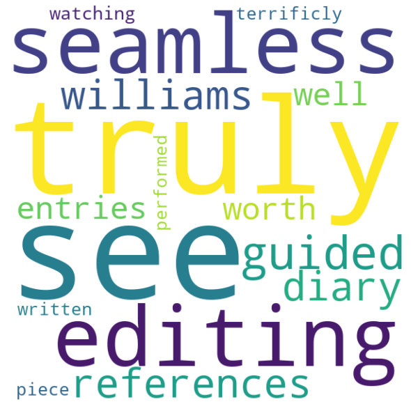

```python
from wordcloud import WordCloud, STOPWORDS
import matplotlib.pyplot as plt

textoWC = ' '.join(words)

wordcloud = WordCloud(width = 600, height = 600,
                background_color ='white',
                stopwords = STOPWORDS,# max_words=200,
                relative_scaling =0,
                min_font_size = 10).generate(textoWC)

plt.figure(figsize = (8, 8), facecolor = None)
plt.imshow(wordcloud, interpolation='bilinear')
plt.axis("off")
plt.tight_layout(pad = 0)

plt.show()
```

## Gensim

Es una librería para el procesamiento de lenguaje natural creada por Radim Řehůřek. El punto fuerte de Gensim es el modelado de temas. Es decir, puede identificar automáticamente de que tratan un conjunto de documentos. Además, Gensim es útil para construir o importar representaciones de vectores distribuidas tales como word2vec. También podemos usar Gensim para analizar la similaridad entre documentos, lo que es muy útil cuando realizamos búsquedas. Para aprender más, mira los tutoriales de Gensim (en inglés).

```python
!pip install gensim
```

[output not shown]

```python
import gensim
from gensim import corpora
from pprint import pprint

# How to create a dictionary from a list of sentences?
documents = ["The Saudis are preparing a report that will acknowledge that",
             "Saudi journalist Jamal Khashoggi's death was the result of an",
             "interrogation that went wrong, one that was intended to lead",
             "to his abduction from Turkey, according to two sources."]

# Tokenize(split) the sentences into words
texts = [[text for text in doc.split()] for doc in documents]

# Create dictionary
dictionary = corpora.Dictionary(texts)

# Get information about the dictionary
print(dictionary.token2id)
#> Dictionary(33 unique tokens: ['Saudis', 'The', 'a', 'acknowledge', 'are']...)
```

```
{'Saudis': 0, 'The': 1, 'a': 2, 'acknowledge': 3, 'are': 4, 'preparing': 5, 'report': 6, 'that': 7, 'will': 8, 'Jamal': 9, "Khashoggi's": 10, 'Saudi': 11, 'an': 12, 'death': 13, 'journalist': 14, 'of': 15, 'result': 16, 'the': 17, 'was': 18, 'intended': 19, 'interrogation': 20, 'lead': 21, 'one': 22…
```

## spaCy

Es la librería de procesamiento natural más rápida que existe. Está diseñada para usarse en aplicaciones reales y extraer información relevante. spaCy también es muy útil para preparar texto para otras tareas de aprendizaje automático. Por ejemplo, podemos preparar los datos para usarlos con TensorFlow, PyTorch, scikit-learn, Gensim, etc. Con spaCy también vamos a poder construir modelos lingüísticos estadísticos sofisticados para muchos de los problemas de procesamiento de lenguaje natural. Para saber más, mira la documentación de spaCy (en inglés).

```python
!pip install spacy
```

[output not shown]

```python
!python -m spacy download en_core_web_sm
```

```
     |████████████████████████████████| 13.7 MB 125 kB/s eta 0:00:01
✔ Download and installation successful
You can now load the package via spacy.load('en_core_web_sm')
```

```python
import spacy
nlp = spacy.load('en_core_web_sm')
```

```python
file_name = 'programming_quotes.txt'
introduction_file_text = open(file_name).read()
introduction_file_doc = nlp(introduction_file_text)

# Extract tokens for the given doc
print ([token.text for token in introduction_file_doc])
```

```
['"', 'Debugging', 'is', 'twice', 'as', 'hard', 'as', 'writing', 'the', 'code', 'in', 'the', 'first', 'place', '.', 'Therefore', ',', 'if', 'you', 'write', 'the', 'code', 'as', 'cleverly', 'as', 'possible', ',', 'you', 'are', ',', 'by', 'definition', ',', 'not', 'smart', 'enough', 'to', 'debug', 'it…
```